# Infix, Prefix and Postfix Expressions

#### Berikut contoh ekspressi aritmatik **infix** dan konversinya ke **prefix** dan **postfix**.

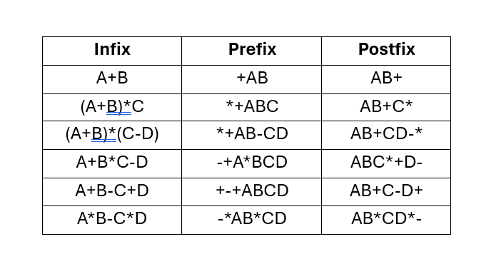

## 1.Infix to Postfix Expression

Diberikan sebuah string s yang mewakili ekspresi infix ("operand1 operator operand2"), Ubahlah ke notasi postfixnya ("operand1 operand2 operator").

Catatan: Urutan prioritasnya adalah sebagai berikut: (^) memiliki prioritas tertinggi dan dievaluasi dari kanan ke kiri, (* dan /) berada di urutan berikutnya dengan asosiatif dari kiri ke kanan, dan (+ dan -) memiliki prioritas terendah dengan asosiatif dari kiri ke kanan.

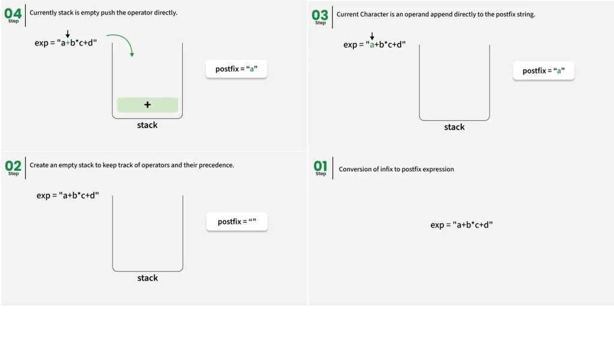

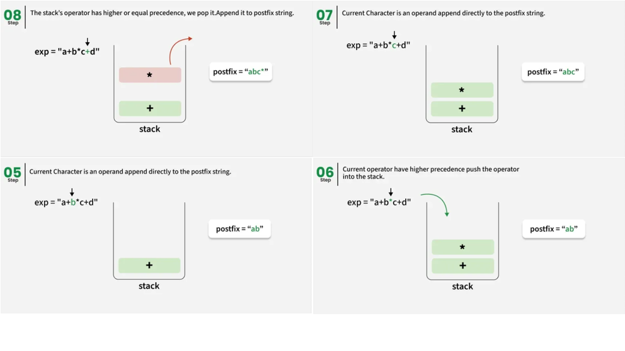

#### contoh:

Input: s = "a*(b+c)/d"

Output: abc+*d/

**Penjelasan:** Ekspresi tersebut adalah a * (b + c) / d. Pertama, di dalam tanda kurung, b + c menjadi bc+. Sekarang ekspresi tersebut terlihat seperti a * (bc+) / d. Selanjutnya, kalikan a dengan (bc+), sehingga menjadi abc+* . Terakhir, bagi hasil ini dengan d, sehingga menjadi abc+*d/.

Input: s = "a+b*c+d"

Output: abc*+d+

**Penjelasan:** Ekspresi a + b * c + d dikonversi dengan terlebih dahulu melakukan b * c → bc*, kemudian menambahkan a → abc*+, dan akhirnya menambahkan d → abc*+d+.

#### Bagaimana Mempertahankan Prioritas dan Asosiativitas?

```python
def prioritas(operator):
    if operator == '+' or operator == '-':
        return 1
    elif operator == '*' or operator == '/':
        return 2
    elif operator == '^':
        return 3
    else:
        return 0


def infix_ke_postfix(expresi):
    stack = []
    output = []
    for karakter in expresi:
        if karakter.isalnum():
            output.append(karakter)
        elif karakter == '(':
            stack.append(karakter)
        elif karakter == ')':
            while stack and stack[-1] != '(':
                output.append(stack.pop())
            stack.pop()  # buang "("
        else:
            while (stack and prioritas(stack[-1]) >= prioritas(karakter)):
                output.append(stack.pop())
            stack.append(karakter)
    while stack:
        output.append(stack.pop())

    return ''.join(output)


infix = "A+B*C"
hasil = infix_ke_postfix(infix)

print("Infix  :", infix)
print("Postfix:", hasil)
```

```
Infix  : A+B*C
Postfix: ABC*+
```

## 2.Infix To Prefix Notation

Diberikan sebuah string s yang mewakili ekspresi infiks ("operand1 operator operand2"), Ubahlah string tersebut menjadi notasi prefiksnya ("operator operand1 operand2").

**Catatan:** Urutan prioritasnya adalah sebagai berikut: (^) memiliki prioritas tertinggi dan dievaluasi dari kanan ke kiri, (* dan /) berada di urutan berikutnya dengan asosiatif dari kiri ke kanan, dan (+ dan -) memiliki prioritas terendah dengan asosiatif dari kiri ke kanan.

**Contoh:**

Input: s = " a*(b+c)/d " Output: /*a+bcd  
Penjelasan: Ekspresi infiksnya adalah a*(b+c)/d. Pertama, di dalam tanda kurung, b + c menjadi +bc. Sekarang ekspresinya terlihat seperti a*(+bc)/d. Selanjutnya, kalikan a dengan (+bc), sehingga menjadi *a+bc. Terakhir, bagi hasil ini dengan d, sehingga menjadi /*a+bcd.

#### Using Stack - O(n) Time and O(n) Space (Menggunakan Stack - Waktu O(n) dan Ruang O(n))

Ide dasarnya adalah memindai ekspresi dari kanan ke kiri, langsung menempatkan operan (a, b, c…) ke dalam hasil sesuai dengan kemunculannya. Operator (+, -, *, /, ^) ditangani menggunakan tumpukan (stack) sehingga prioritas dan asosiatifitas tetap terjaga.

##### Bagaimana Mempertahankan Prioritas dan Asosiativitas?

Untuk menjaga prioritas dan asosiatifitas, ketika operator baru muncul, bandingkan dengan operator yang berada di atas tumpukan. Keluarkan operator dari tumpukan jika memiliki prioritas lebih tinggi, atau jika memiliki prioritas yang sama dan operator baru tersebut asosiatif kanan (^). Operator asosiatif kiri (+, -, *, /) tidak menyebabkan pengeluaran. Masukkan operator baru ke dalam tumpukan. Untuk tanda kurung (saat memindai dari kanan ke kiri), masukkan ')' ke dalam tumpukan, dan ketika '(' ditemukan, keluarkan operator hingga ')' ditemukan.

Terakhir, keluarkan semua operator yang tersisa dari tumpukan dan tambahkan ke hasilnya. Kemudian, balikkan hasilnya untuk mendapatkan ekspresi awalan yang benar.

```python
# function to return precedence of operators
def precedence(c):
    if c == '^':
        return 3
    elif c in ('*', '/'):
        return 2
    elif c in ('+', '-'):
        return 1
    else:
        return -1

# function to check if operator is right-associative
def isRightAssociative(c):
    return c == '^'

# function to check if a character is an operator
def isOperator(c):
    return c in "+-*/^"

# function to convert infix expression to prefix
def infixToPrefix(s):
    st = []
    result = []

    # scan from right to left
    for c in reversed(s):
        if c.isalnum():
            result.append(c)
        elif c == ')':
            st.append(c)
        elif c == '(':
            while st and st[-1] != ')':
                result.append(st.pop())
            if st:
                st.pop()  # remove ')'
        elif isOperator(c):
            while (st and isOperator(st[-1]) and
                  (precedence(st[-1]) > precedence(c) or
                  (precedence(st[-1]) == precedence(c) and isRightAssociative(c)))):
                result.append(st.pop())
            st.append(c)

    # pop remaining operators
    while st:
        result.append(st.pop())

    # reverse at the end to get correct prefix
    return ''.join(reversed(result))

if __name__ == "__main__":
    s = "a*(b+c)/d"
    print(infixToPrefix(s))
```

```
/*a+bcd
```

```python
s = "(a*b+c/d)"

data = list(s)
data.reverse()
stack = []
hasil = []

for c in data:

    if c == 'a' or c == 'b' or c == 'c' or c == 'd':
        hasil.append(c)

    elif c == ')':
        stack.append(c)

    elif c == '(':
        while stack[-1] != ')':
            hasil.append(stack.pop())
        stack.pop()

    else:
        while stack and stack[-1] != ')':
            hasil.append(stack.pop())
        stack.append(c)

while stack:
    hasil.append(stack.pop())

hasil.reverse()

print("Infix  :", s)
print("Prefix :", "".join(hasil))
```

```
Infix  : (a*b+c/d)
Prefix : *a+b/cd
```

#### Using Postfix and Reverse Method - O(n) Time and O(n) (Space Menggunakan Metode Postfix dan Reverse - Waktu O(n) dan Ruang O(n))

Untuk mengubah ekspresi infiks menjadi prefiks, kita menggunakan metode infiks-ke-postfiks dengan sedikit modifikasi.

1. Pertama, kita **reverse** ekspresi infiks karena prefiks dievaluasi dari kanan ke kiri (kebalikan dari postfiks).
2. Saat membalikkan, kita **menukar '(' with ')'** untuk mempertahankan pengelompokan subekspresi yang benar.
3. Sekarang, kita mengubah ekspresi yang telah dimodifikasi ini menjadi postfix menggunakan metode berbasis tumpukan standar.
4. Terakhir, kita **reverse** ekspresi postfix yang dihasilkan. Ini memberikan bentuk prefix yang benar.

**Catatan:** Awalan = kebalikan( akhiran( kebalikan(infiks) ) )

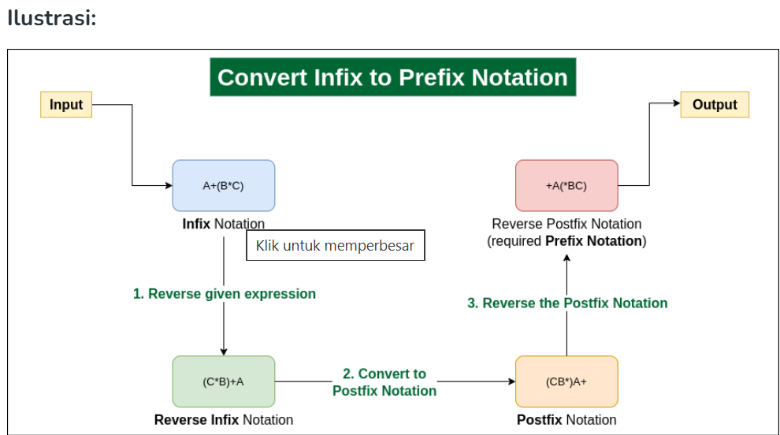

```python
# function to return precedence
def precedence(c):
    if c == '^': return 3
    elif c in ['*', '/']: return 2
    elif c in ['+', '-']: return 1
    else: return -1

def isOperator(c):
    return c in ['+', '-', '*', '/', '^']

# check if operator is right-associative
def isRightAssociative(c):
    return c == '^'

# function to convert infix to prefix
# using reverse-trick
def infixToPrefix(s):
    # reverse string
    s = s[::-1]

    # swap ( and )
    s = ''.join(')' if c == '(' else '(' if c == ')' else c for c in s)

    st = []
    result = []

    # infix to postfix on reversed string
    for c in s:
        if c.isalnum():
            result.append(c)
        elif c == '(':
            st.append(c)
        elif c == ')':
            while st and st[-1] != '(':
                result.append(st.pop())
            if st: st.pop()
        elif isOperator(c):
            while (st and st[-1] != '(' and
                   (precedence(st[-1]) > precedence(c) or
                   (precedence(st[-1]) == precedence(c) and isRightAssociative(c)))):
                result.append(st.pop())
            st.append(c)

    while st:
        result.append(st.pop())

    # reverse result
    return ''.join(result[::-1])

if __name__ == "__main__":
    s = "a*(b+c)/d"
    print(infixToPrefix(s))
```

```
/*a+bcd
```

# 3.Prefix to Infix Conversion

**Infix** : Suatu ekspresi disebut ekspresi infiks jika operator muncul di antara operan dalam ekspresi tersebut. Bentuknya sederhana, yaitu (operan1 operator operan2). Contoh: (A+B) * (CD)

**Awalan (Prefix )**: Suatu ekspresi disebut ekspresi awalan jika operator muncul dalam ekspresi sebelum operan. Bentuknya sederhana, yaitu (operator operan1 operan2). Contoh: *+AB-CD (Infiks: (A+B) * (CD))

Diberikan sebuah ekspresi Prefiks, ubahlah menjadi ekspresi Infiks. Komputer biasanya melakukan perhitungan baik dalam bentuk prefiks maupun postfix (biasanya postfix). Namun bagi manusia, ekspresi Infiks lebih mudah dipahami daripada ekspresi prefiks. Oleh karena itu, konversi diperlukan agar manusia dapat memahaminya.

**Contoh:**

**Input** : Prefix : *+AB-CD

**Output** : Infix : ((A+B)*(C-D))

**Input** : Prefix : *-A/BC-/AKL

**Output** : Infix : ((A-(B/C))*((A/K)-L))

[figure not shown]

Algorithm for Prefix to Infix:

- Bacalah ekspresi Awalan secara terbalik (dari kanan ke kiri)
- Jika simbol tersebut merupakan operan, maka masukkan ke dalam Stack.
- Jika simbol tersebut adalah operator, maka keluarkan dua operand dari Stack.
- Buat string dengan menggabungkan kedua operand dan operator di antaranya.
- string = (operand1 + operator + operand2) Dan masukkan kembali string hasil tersebut ke Stack.
- Ulangi langkah-langkah di atas hingga akhir ekspresi Awalan.
- Pada akhirnya, tumpukan hanya akan berisi 1 string, yaitu string hasil.

```python
# Python Program to convert prefix to Infix
def prefixToInfix(prefix):
    stack = []

    # read prefix in reverse order
    i = len(prefix) - 1
    while i >= 0:
        if not isOperator(prefix[i]):

            # symbol is operand
            stack.append(prefix[i])
            i -= 1
        else:

            # symbol is operator
            str = "(" + stack.pop() + prefix[i] + stack.pop() + ")"
            stack.append(str)
            i -= 1

    return stack.pop()

def isOperator(c):
    if c == "*" or c == "+" or c == "-" or c == "/" or c == "^" or c == "(" or c == ")":
        return True
    else:
        return False

# Driver code
if __name__=="__main__":
    str = "*-A/BC-/AKL"
    print(prefixToInfix(str))
```

```
((A-(B/C))*((A/K)-L))
```

### Soal - Soal

1. Buatlah sebuah fungsi bernama evaluasi_postfix(ekspresi) yang menerima sebuah string ekspresi Postfix (tiap elemen dipisahkan spasi) dan mengembalikan hasil perhitungan matematikanya. Fungsi ini hanya perlu mendukung operator +, -, *, dan /.

```python
def evaluasi_postfix(ekspresi):
    stack = []
    token_list = ekspresi.split()

    for token in token_list:
        if token.lstrip('-').isdigit():
            stack.append(int(token))
        else:
            angka2 = stack.pop()
            angka1 = stack.pop()

            if token == '+':
                stack.append(angka1 + angka2)
            elif token == '-':
                stack.append(angka1 - angka2)
            elif token == '*':
                stack.append(angka1 * angka2)
            elif token == '/':
                stack.append(int(angka1 / angka2))

    return stack.pop()

print(evaluasi_postfix("2 3 1 * + 9 -"))
```

```
-4
```

2. Buatlah sebuah fungsi bernama evaluasi_prefix(ekspresi) yang menerima string ekspresi Prefix dan mengembalikan hasil perhitungannya. Petunjuk: Logikanya mirip dengan Postfix, namun kamu harus membaca ekspresi dari kanan ke kiri (terbalik).

```python
def evaluasi_prefix(ekspresi):
    stack = []
    token_list = ekspresi.split()[::-1]

    for token in token_list:
        if token.lstrip('-').isdigit():
            stack.append(int(token))
        else:
            angka1 = stack.pop()
            angka2 = stack.pop()

            if token == '+':
                stack.append(angka1 + angka2)
            elif token == '-':
                stack.append(angka1 - angka2)
            elif token == '*':
                stack.append(angka1 * angka2)
            elif token == '/':
                stack.append(int(angka1 / angka2))

    return stack.pop()

print(evaluasi_prefix("- + 2 * 3 1 9"))
```

```
-4
```

3. Buatlah fungsi postfix_ke_infix(ekspresi) yang mengubah ekspresi Postfix menjadi Infix. Setiap kali sebuah operasi digabungkan, kamu harus menambahkan tanda kurung () untuk memastikan urutan operasi (presedensi) tetap benar.

```python
def postfix_ke_infix(ekspresi):
    stack = []
    token_list = ekspresi.split()
    operator = set(['+', '-', '*', '/', '^'])

    for token in token_list:
        if token not in operator:
            stack.append(token)
        else:
            op2 = stack.pop()
            op1 = stack.pop()
            ekspresi_baru = f"({op1} {token} {op2})"
            stack.append(ekspresi_baru)

    return stack.pop()

print(postfix_ke_infix("A B C * +"))
```

```
(A + (B * C))
```

4. Buatlah sebuah fungsi postfix_ke_prefix(ekspresi) yang menerima ekspresi Postfix dan mengubahnya menjadi Prefix.

```python
def postfix_ke_prefix(ekspresi):
    stack = []
    token_list = ekspresi.split()
    operator = set(['+', '-', '*', '/', '^'])

    for token in token_list:
        if token not in operator:
            stack.append(token)
        else:
            op2 = stack.pop()
            op1 = stack.pop()
            ekspresi_baru = f"{token} {op1} {op2}"
            stack.append(ekspresi_baru)

    return stack.pop()

print(postfix_ke_prefix("A B + C *"))
```

```
* + A B C
```

5. Buat fungsi infix_ke_postfix(ekspresi) yang mengkonversi ekspresi Infix ke Postfix. Asumsikan input hanya berisi huruf sebagai operand, operator aritmatika (+, -, *, /), dan tanda kurung buka/tutup. Kamu harus mempertimbangkan tingkat prioritas operator (Perkalian/Pembagian lebih tinggi dari Penjumlahan/Pengurangan).

```python
def infix_ke_postfix(ekspresi):
    prioritas = {'+': 1, '-': 1, '*': 2, '/': 2, '(': 0}
    stack_operator = []
    hasil_postfix = []
    token_list = ekspresi.split()

    for token in token_list:
        if token.isalnum():
            hasil_postfix.append(token)
        elif token == '(':
            stack_operator.append(token)
        elif token == ')':
            operator_atas = stack_operator.pop()
            while operator_atas != '(':
                hasil_postfix.append(operator_atas)
                operator_atas = stack_operator.pop()
        else:
            while (len(stack_operator) != 0) and (prioritas[stack_operator[-1]] >= prioritas[token]):
                hasil_postfix.append(stack_operator.pop())
            stack_operator.append(token)

    while len(stack_operator) != 0:
        hasil_postfix.append(stack_operator.pop())

    return " ".join(hasil_postfix)

print(infix_ke_postfix("A + B * C"))
print(infix_ke_postfix("( A + B ) * C"))
```

```
A B C * +
A B + C *
```